# Data Science Profiles

## 0.10 Principal Component Analysis (PCA)

## 0.11 PCA

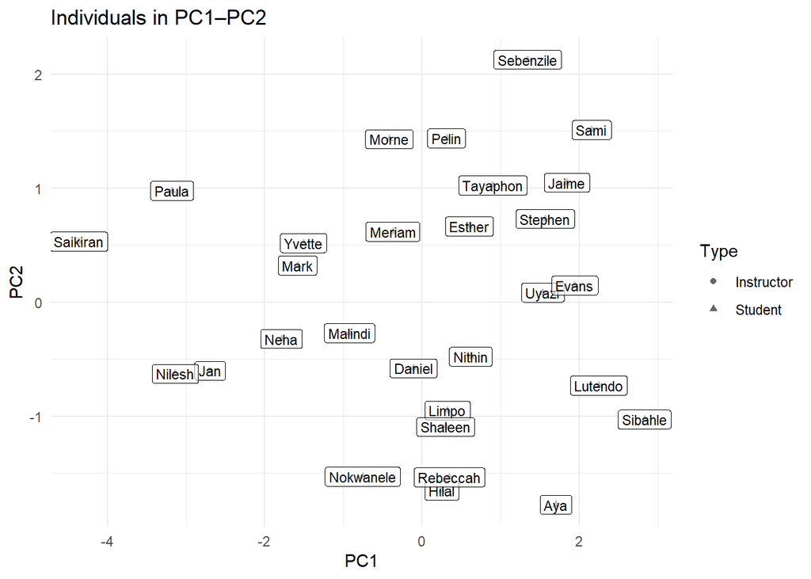

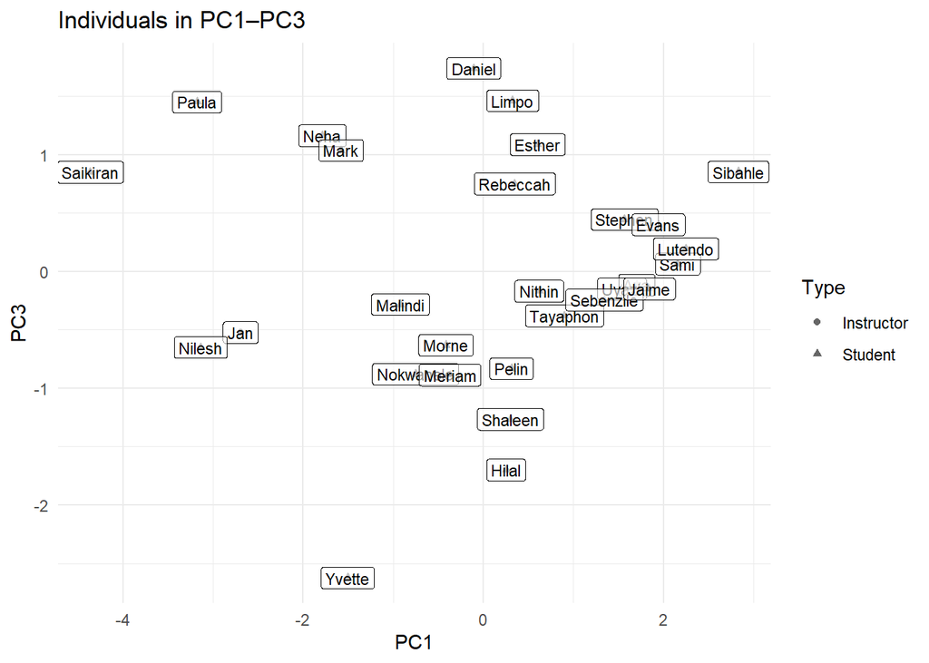

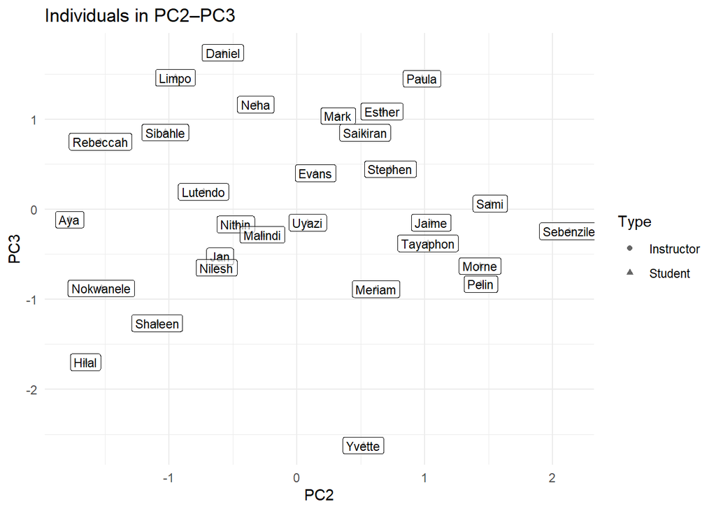

** Individuals who are closer together in these PCA plots have more similar skill profiles, while those farther apart differ more strongly. The 2025 labels help highlight which students cluster together and which stand out.

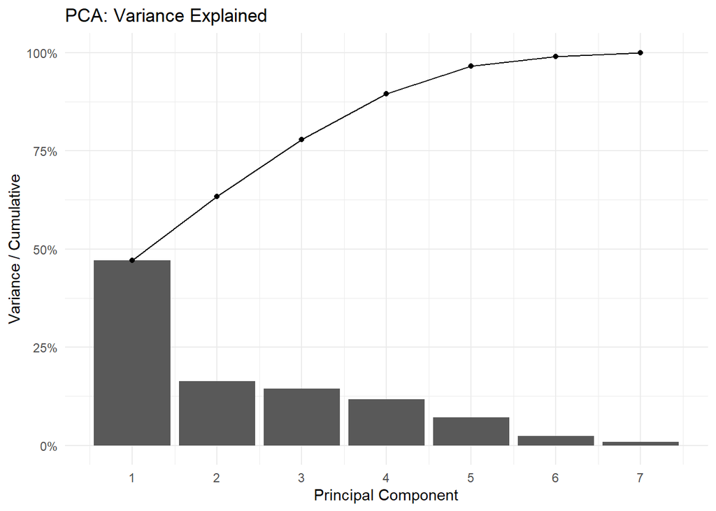

PCA: Variance explained per component

**Interpretation.** The first principal component (PC1) explains the largest share of variation across skills, and the first two components together capture most of the overall structure. This means many skill areas tend to vary together rather than independently.